# Black Thrive Shared Measurement System Lambeth

November 2021

# Overview

This document presents the findings for the first version of Black Thrive Global’s new Shared Measurement System dashboard for Lambeth. The aim of the dashboard is to quantify racial inequality in Lambeth by comparing various indicators for the Black population with the White population. Doing so makes it possible to identify the aspects of life in Lambeth where inequality is manifest and to highlight where change is needed. By routinely reassessing these indicators, it will also be possible to track if and how these inequalities change over time.

The indicators, and the sources of their data, are presented in the Appendix.

# Procedure and Results

The data were analysed to determine whether the likelihood of each indicator outcome differed for Black versus White individuals. From this analysis is it possible to produce a relative risk ratio, which describes how much more or less likely an outcome is for the Black population compared to the White population. A ratio of exactly 1 indicates that the likelihood of the outcome is the same for both the Black population and the White population. A ratio of less than 1 indicates that the outcome is *less likely* for the Black population compared to the White population, and a ratio of more than 1 indicates the outcome is *more likely* for the Black population compared to the White population.

The plot below makes the results straightforward to interpret. Points to the left of the orange line indicate outcomes that are *less likely* for the Black population compared to the White population. Points to the right of the orange line indicate outcomes that are *more likely* for the Black population compared to the White population. Points that are close to the orange line (where the black bar coming from the point touches the orange line) indicate outcomes that are *just as likely* for the Black population as they are for the White population.

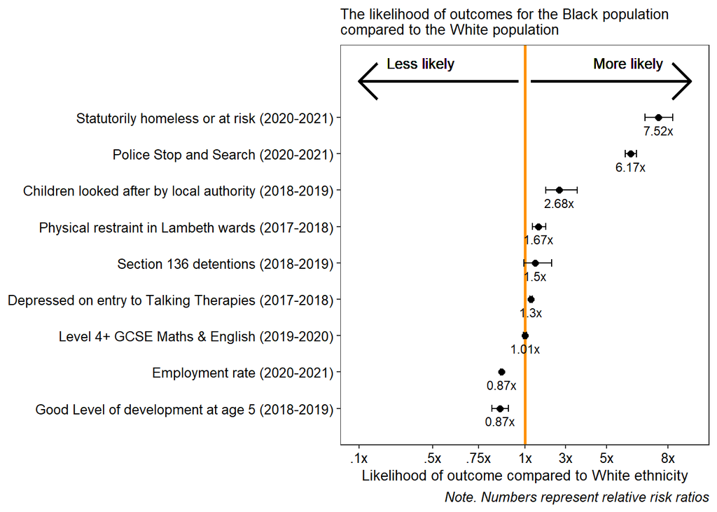

# Indicator breakdowns

The above results are broken down below. For each indicator, the number of individuals of each ethnicity is plotted. A percentage is also presented, which represents the number as a proportion of the total population of each ethnicity.

## Children reaching a good level of development at age 5

In 2018-2019, 67.46% of Black children reached a Good Level of Development, compared to 77.98% of White children. Black children were 13.48% less likely than White children to reach a Good Level of Development at age 5.

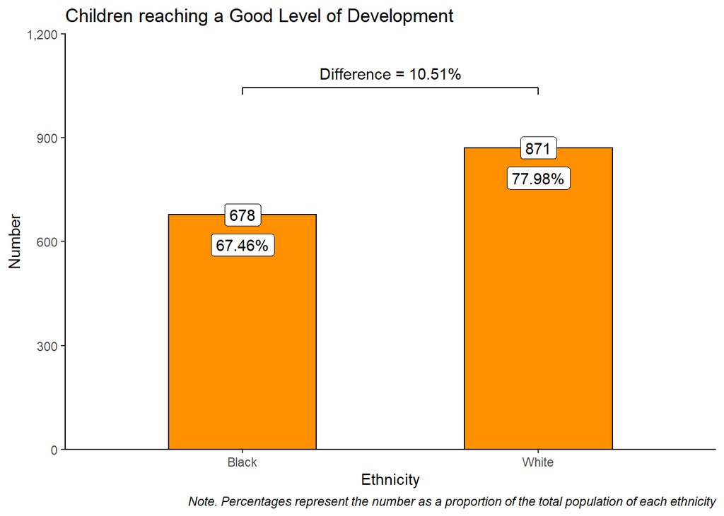

## Children looked after by local authority

In the 2018-2019 financial year, 0.75% of Black children were looked after by the local authority, compared to 0.28% of White children. Black children were 168% (i.e., 2.68 times) more likely than White children to be looked after the local authority.

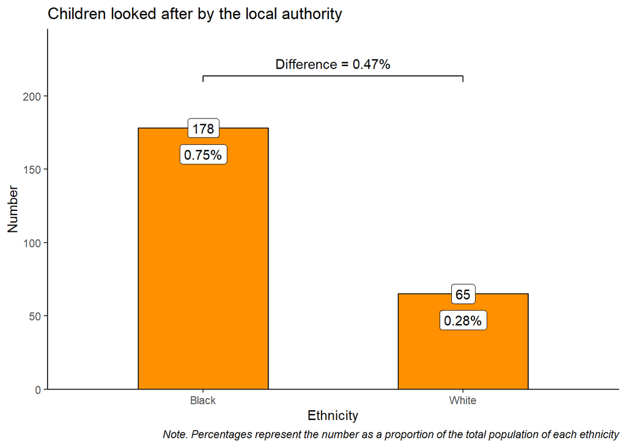

## Pupils achieving Level 4+ in GCSE Maths and English

In the 2019/2020 academic year, 68.3% of Black pupils and 67.6% of White pupils achieved at least Level 4 in GCSE Maths and English. This difference was non-significant.

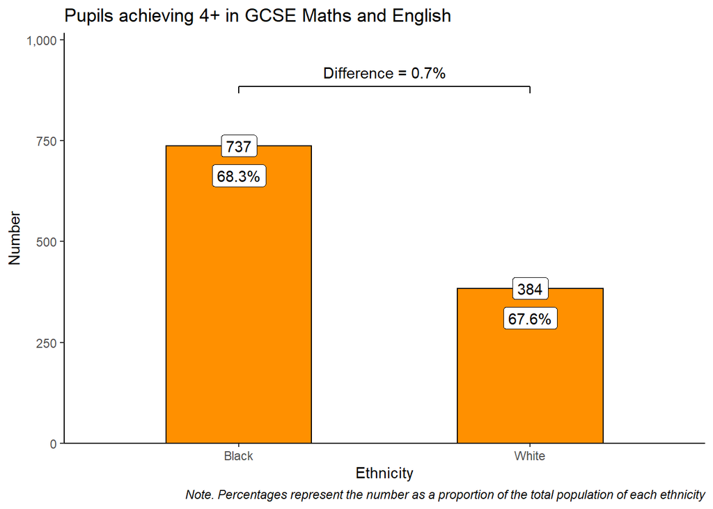

## Employment

In 2020, the employment rate amongst Black 16-64 year olds was 71.5%, compared to 81.8% for White individuals. Black 16-64 year olds were 12.59% less likely than White 16-64 year olds to be in employment.

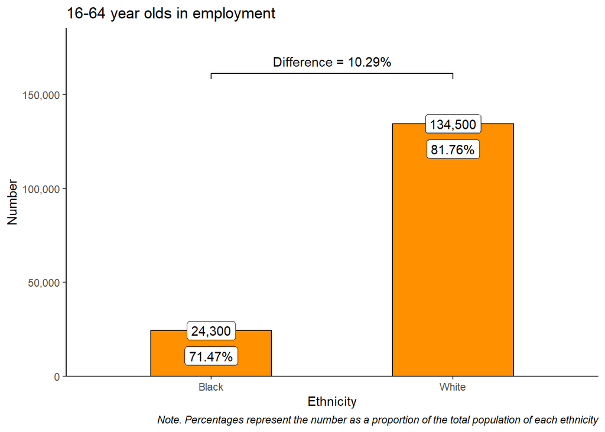

## Percentage of households homeless or at risk of becoming homeless

In the 2020/21 financial year, 2.84% of Black households were assessed as statutorily homeless or at risk of becoming homeless, compared to 0.38% of White households. Black households were 652% (i.e., 7.52 times) more likely than White households to be statutorily homeless or at risk of becoming homeless.

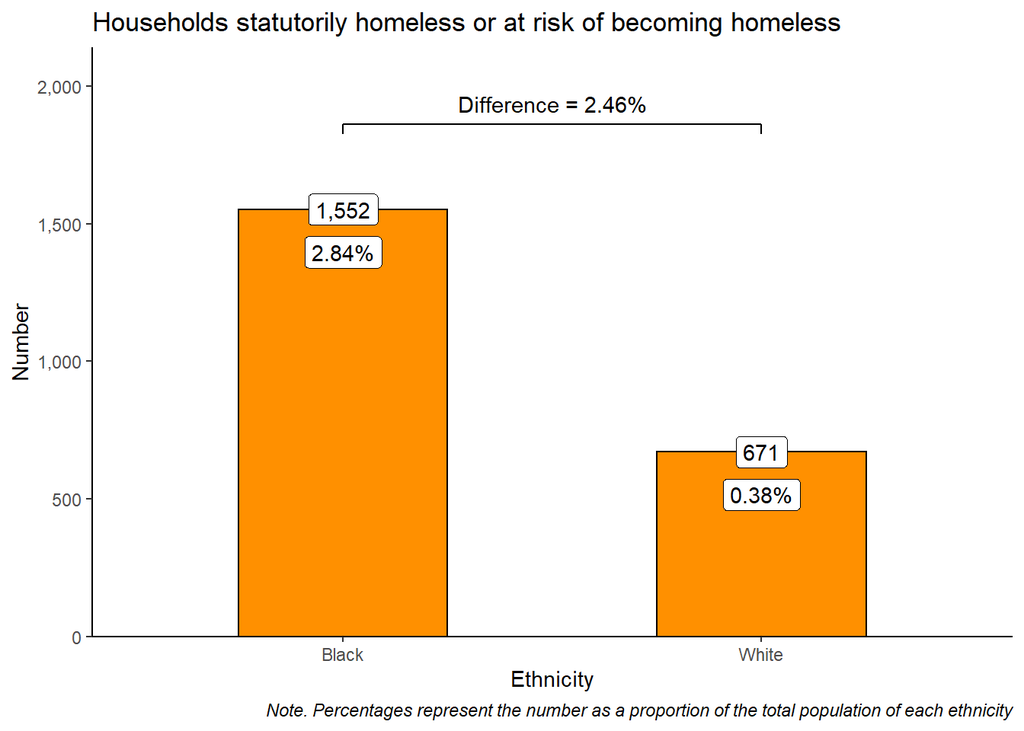

## Individuals subject to detention per Section 136 of the Mental Health Act

In 2018-2019, the rate of individuals detained under Section 136 of the Mental Health act was 60 per 100,000 (0.06%) for Black individuals, compared to 40 per 100,000 (0.04%) for White individuals. There was no difference between Black and White individuals in Section 136 detention rate.

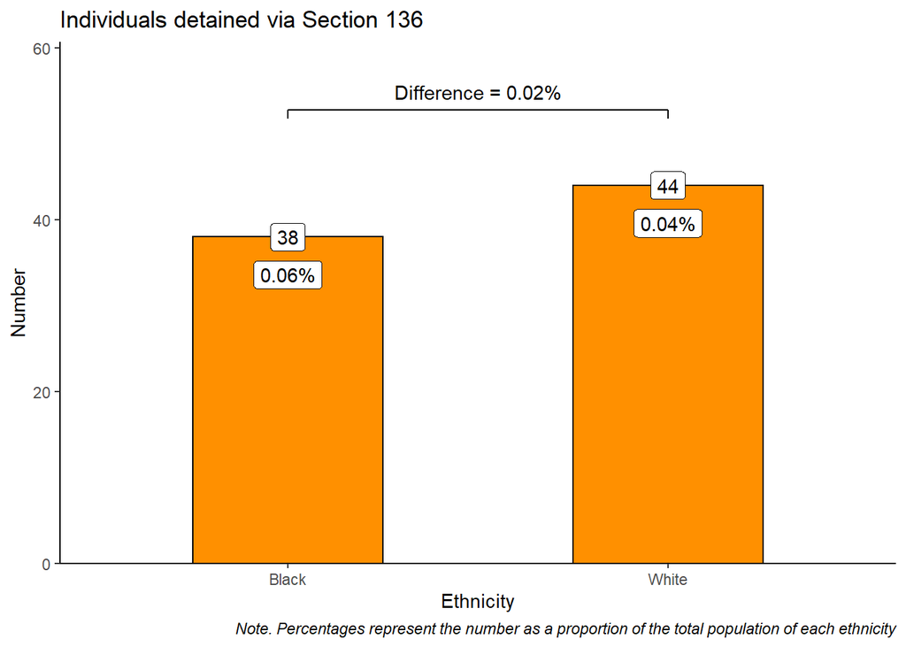

## Individuals moderately to severely depressed on entering Talking Therapies

In 2017-2018, 65% of Black individuals were moderately to severely depressed before starting Talking Therapies, compared to 50% of White individuals. Black individuals were 30% (i.e., 1.3 times) more likely than White individuals to be moderately to severely depressed when they start Talking Therapies.

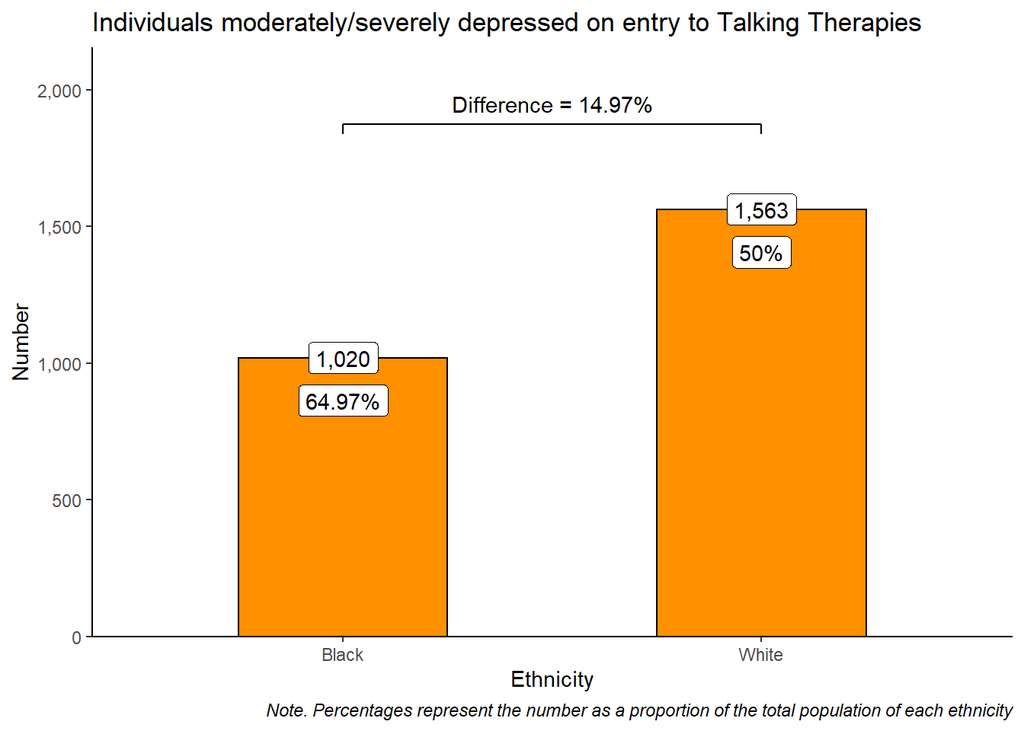

## Individuals physically restrained on Lambeth Wards

In 2017-2018, 65% of Black Lambeth ward patients had physical restraint used on them, compared to 39% of White patients. Black ward patients were 67% (i.e., 1.67 times) more likely than White ward patients to be physically restrained.

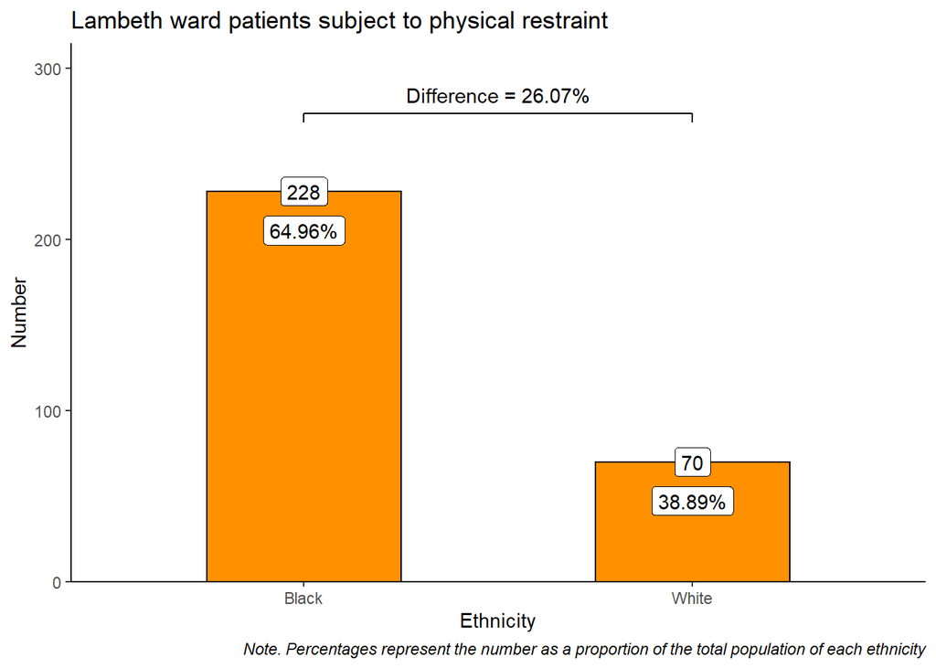

## Individuals subject to Police Stop and Search

In the period from September 2020 to August 2021, 9.49% of Black individuals in Lambeth were stopped and searched by Police, compared to 1.54% of White individuals. Black individuals were 517% (i.e., 6.17 times) more likely than White individuals to be stopped and searched by Police.

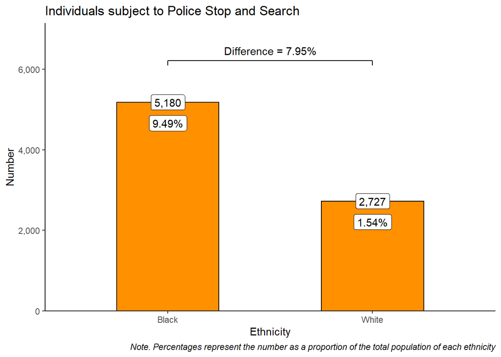

# Authors

This document was produced by the Research Team at Black Thrive Global:

**Jolyon Miles-Wilson**

**Dr Celestin Okoroji**

Any questions, comments, and/or feedback on any aspect of this analysis are greatly appreciated. Please contact us at research@blackthrive.org, FAO Jolyon Miles-Wilson.

# Supporting information

The R code that produced this report is available on Github [here](https://github.com/BlackThrive/lambeth_sms). A separate methodology paper that provides more detail on the data and analysis procedure is available [here](https://github.com/BlackThrive/sms_methodology).

# Appendix

| Indicator | Date | Source | Note |
| --- | --- | --- | --- |
| Children reaching a Good Level of Development at age 5 | 2018/19 academic year | Lambeth Council, Education Research and Statistics Department | Analyses based on crosstabulations derived from data sourced by Lambeth Public Health |
| Children looked after by local authority | 2018/19 | [Children looked after in England including adoption](https://www.gov.uk/government/statistics/children-looked-after-in-england-including-adoption-2018-to-2019) |  |
| Pupils achieving at least Level 4 in GCSE Maths & English | 2019/20 academic year | [Key Stage 4 performance](https://explore-education-statistics.service.gov.uk/find-statistics/key-stage-4-performance-revised#dataDownloads-1) |  |
| 16-64 year olds in employment | 12 months to March 2021 | [Annual Population Survey (NOMIS, Office for National Statistics)](https://www.nomisweb.co.uk/datasets/apsnew) |  |
| Households that are statutorily homeless or at risk of becoming homeless | 2020/2021 financial year | [Live tables on homelessness; Detailed local authority level tables](https://www.gov.uk/government/statistical-data-sets/live-tables-on-homelessness#homelessness-summary-local-authority-level-tables) |  |
| Individuals subject to detention per Section 136 of the Mental Health Act | 2018/19 | EPJS, South London and Maudsley NHS Foundation Trust | Analyses based on crosstabulations derived from data sourced by Lambeth Public Health |
| Individuals moderately to severely depressed prior to starting Talking Therapies | 2017/18 | IAPTUS, South London and Maudsley NHS Foundation Trust | Analyses based on crosstabulations derived from data sourced by Lambeth Public Health |
| Lambeth ward patients physically restrained | 2017/18 | DATIX, South London and Maudsley NHS Foundation Trust | Analyses based on crosstabulations derived from data sourced by Lambeth Public Health |
| Individuals subject to Police Stop and Search | 12 months to August 2021 | [Metropolitan Police Stop and Search Dashboard Data](https://data.london.gov.uk/dataset/mps-stop-and-search-public-dashboard-data) |  |
| Lambeth adult population estimates | 2021 | [Annual Population Survey](https://www.nomisweb.co.uk/datasets/apsnew) |  |
| Lambeth child population estimates | 2019 | [Greater London Authority Ethnic group population projections](https://data.london.gov.uk/dataset/ethnic-group-population-projections) |  |